# Practica 2: Ajuste, Residuos y Correlación

Estadistica Multivariada - Sociología FACSO Universidad de Chile

Juan Carlos Castillo & Alejandro Plaza

# 1 Introducción

En esta práctica se continua con ejercicios de regresión simple, enfocados en ajuste, residuos y relación con correlación. Están basados principalmente en el ejemplo de Darlington & Hayes cap. 2 (The simple regression model).

# 2 Datos

Los datos a utilizar son los mismos que los de la práctica 1, corresponden a un ejemplo ficticio de 23 casos (individuos) y sus datos en dos variables relacionadas con un juego: Las dos variables de esta base de datos son el número de veces que se ha jugado antes (X) y el número de puntos ganados (Y). El archivo de datos original es golf.txt.

```r
datos<- read.csv("https://juancarloscastillo.github.io/metsoc-facsouchile/documents/practicas/1_regsimp/golf.txt", sep="")
```

Y generamos un gráfico para recordar la distribución de los datos:

```r
pacman::p_load(ggplot2,plotly)

# basic scatterplot
g=ggplot(datos, aes(x=juegos, y=puntos)) +
  geom_point()

gg=ggplotly(g)
gg
```

[interactive chart not shown]

## 2.2 Modelo y cálculo de parámetros

El modelo de regresión entonces se relaciona con una ecuación de la recta, o recta de regresión, que se puede definir en términos simples de la siguiente manera:

$$\widehat{Y}=b_{0} +b_{1}X$$

```r
reg1 <-lm(puntos ~juegos, data = datos)
reg1
```

```
##
## Call:
## lm(formula = puntos ~ juegos, data = datos)
##
## Coefficients:
## (Intercept)       juegos
##         2.5          0.5
```

En el formato de la redacción en RMarkdown se pueden presentar los valores de las estimaciones con distintas funciones del paquete **texreg**. Una de ellas es `screenreg`, que ofrece una salida simple en la pantalla:

```r
library(texreg)

screenreg(reg1, custom.model.names = "Variable dependiente: Puntos de Tacataca", # Cambiar nombre del título
       custom.coef.names = c("Intercepto", "Juegos"),   #Cambiar nombre de las variables
       custom.note = "Elaboración propia en base a Golf.txt", #Agregar una nota
       single.row = T #para que la DS este en una linea
       )
```

```
##
## ====================================================
##             Variable dependiente: Puntos de Tacataca
## ----------------------------------------------------
## Intercepto   2.50 (0.46) ***
## Juegos       0.50 (0.13) **
## ----------------------------------------------------
## R^2          0.40
## Adj. R^2     0.38
## Num. obs.   23
## RMSE         1.09
## ====================================================
## Elaboración propia en base a Golf.txt
```

Con la función `htmlreg` es posible generar también una tabla que puede ser publicable en formato html, tal como en el siguiente ejemplo:

```r
htmlreg(reg1, custom.model.names = "Variable dependiente: Puntos de Tacataca", # Cambiar nombre del título
       custom.coef.names = c("Intercepto", "Juegos"),   #Cambiar nombre de las variables
       custom.note = "Elaboración propia en base a Golf.txt", #Agregar una nota
       single.row = T #para que la DS este en una linea
       )
```

Statistical models

|  | **Variable dependiente: Puntos de Tacataca** |  |
| --- | --- | --- |
| Intercepto | 2.50 (0.46)*** |  |
| Juegos | 0.50 (0.13)** |  |
| R<sup>2</sup> | 0.40 |  |
| Adj. R<sup>2</sup> | 0.38 |  |
| Num. obs. | 23 |  |
| RMSE | 1.09 |  |
| Elaboración propia en base a Golf.txt |  |  |

En el contexto de los modelos de regresión, las estimaciones pueden presentarse en un gráfico de coeficientes o **coefplot**.

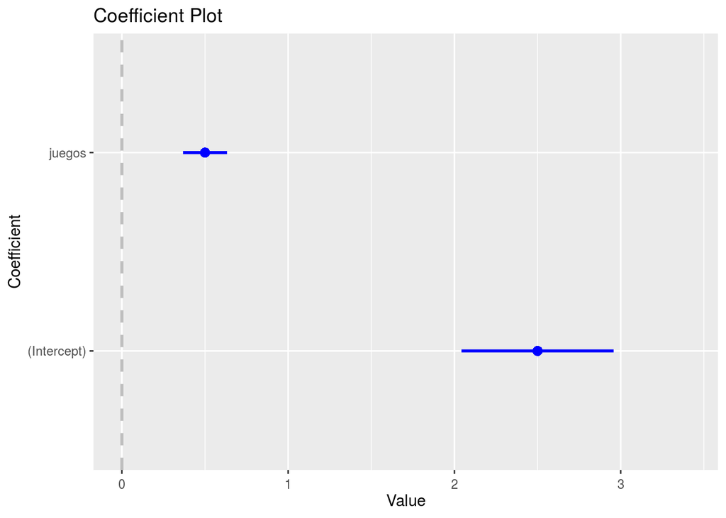

```r
pacman::p_load(coefplot)
coefplot(reg1)
```

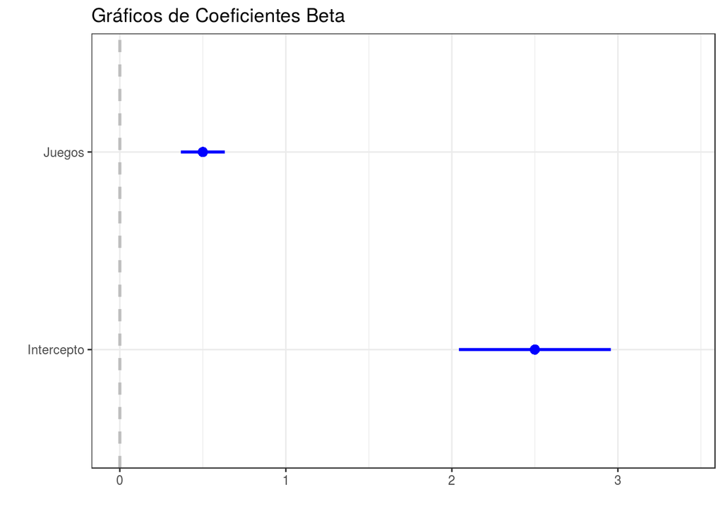

```r
#Modificaciones con ggplot2
coefplot(reg1)+
  scale_y_discrete(name=" ", limits=c("(Intercept)","juegos"),
                   labels=c("Intercepto", "Juegos")) +
  scale_x_continuous(name = " ") +
  ggtitle("Gráficos de Coeficientes Beta")+
  theme_bw()
```

# 3 Bondad de Ajuste: Residuos y $R_{2}$

A partir del método de Mínimos Cuadrados Ordinarios obtenemos una recta que describe un conjunto de datos minimizando las diferencias entre el modelo ajustado a los datos y los datos mismos.

No obstante, incluso cuando se ajusta el mejor modelo puede existir cierta imprecisión, la cual es representada por las diferencias entre los datos observados y los valores predichos por la recta de regresión.

La imprecisión implica evaluar la **Bondad de Ajuste** y se evalua a partir del estadístico $R^2$.

En el siguiente apartado se puede observar la manera de cálcular la predicción de Y (puntos) en base a X (juegos), y almacenarlos en la base de datos, con los respectivos residuos.

```r
#summary(lm(puntos~juegos, data=datos))
#beta=0.5 intercepto=2.5

#Variable de valores predichos
datos$estimado<- (2.5 + datos$juegos*0.5)

# Alternativa por comando
#datos$estimado <- predict(reg1)

#Estimamos el residuo
datos$residuo <- datos$puntos - datos$estimado

# Alternativa por comando
#datos$residuo <- residuals(reg1)

datos %>% select(id, estimado, residuo) %>% head()
```

```
##   id estimado residuo
## 1  1      2.5    -0.5
## 2  2      2.5     0.5
## 3  3      3.0    -1.0
## 4  4      3.0     0.0
## 5  5      3.0     1.0
## 6  6      3.5    -1.5
```

## 3.1 Suma de cuadrados y $R^{2}$

Usando la media como modelo podemos calcular las diferencias entre los valores observados y los valores predichos por la media.

- La suma de las diferencias al cuadrado la llamamos **Suma Total de Cuadrados**:

$$SS_{tot} = \sum(y-\bar{y})^2$$
Y calculamos

```r
ss_tot<- sum((datos$puntos-mean(datos$puntos))^2); ss_tot
```

```
## [1] 42
```

Usando la predicción del modelo OLS podemos llegar a tener una mejor aproximación:

- la suma de las diferencias entre los datos observados y los datos predichos al cuadrado le llamamos **Suma de residuos al cuadrado**:

$$SS_{error} = \sum(y-\hat{y})^2$$
Este valor representa el grado de imprecisión cuando la mejor recta se ajusta a los datos.

```r
ss_err<- sum((datos$puntos - datos$estimado)^2);ss_err
```

```
## [1] 25
```

Cuánto mejor ajusta un modelo OLS sobre el cálculo de la media. Esto se puede estimar la diferencia al cuadrado entre el valor estimado y la media, esto se llama **Suma explicada de cuadrados**

$$SS_{reg} = \sum(\hat{y}-\bar{y})^2$$

```r
ss_reg<-sum((datos$estimado-mean(datos$puntos))^2) ; ss_reg
```

```
## [1] 17
```

A partir de la suma de cuadrados es posible calcular el estadístico $R^{2}$

$$R^2=\frac{SS_{reg}}{SS_{tot}}= 1- \frac{SS_{error}}{SS_{tot}}$$

```r
#Opción 1
ss_reg/ss_tot
```

```
## [1] 0.4047619
```

```r
#Opción 2
1-ss_err/ss_tot
```

```
## [1] 0.4047619
```

```r
#por comando
summary(lm(puntos~juegos, data=datos))$r.squared
```

```
## [1] 0.4047619
```

## 3.2 Visualización

En la siguiente sección se presentan distintas formas de visualizar los residuos a partir del paquete **ggplot2**.

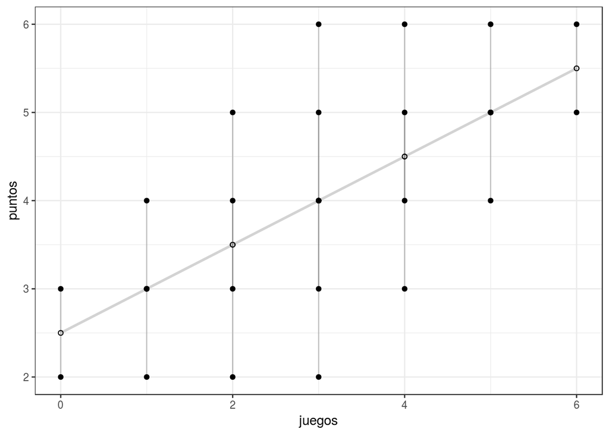

```r
#Visualizacion
library(ggplot2)

ggplot(datos, aes(x=juegos, y=puntos))+
  geom_smooth(method="lm", se=FALSE, color="lightgrey") +#Pendiente de regresion
  geom_segment(aes(xend=juegos, yend=estimado), alpha = .2) + #Distancia entre estimados y datos en lineas
  geom_point() + #Capa 1
  geom_point(aes(y=estimado), shape =1) +
  theme_bw()
```

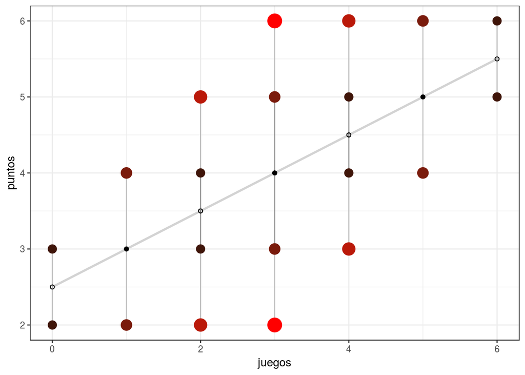

```r
#Opción donde se juega con el tamaño de los puntos y los colores para resalta el tamaño de los residuos.

ggplot(datos, aes(x=juegos, y=puntos))+
  geom_smooth(method="lm", se=FALSE, color="lightgrey") +#Pendiente de regresion
  geom_segment(aes(xend=juegos, yend=estimado), alpha = .2) + #Distancia entre estimados y datos en lineas
  geom_point(aes(color = abs(residuo), size = abs(residuo))) +
  scale_color_continuous(low = "black", high = "red") +
  guides(color = FALSE, size = FALSE) +
   geom_point(aes(y=estimado), shape =1) +
  theme_bw()
```

# 4 El coeficiente de Regresión versus el coeficiente de correlación

tanto $r_{xy}$ y $\beta_1$ son medidas de la relación entre X e Y. Ellas estan relacionadas con la formula de:

$$\beta_1= r_{xy}(S_y/S_x)$$

Es decir:

```r
beta<-cor(datos$juegos,datos$puntos)*(sd(datos$puntos)/sd(datos$juegos));beta
```

```
## [1] 0.5
```

```r
reg1$coefficients[2] #llamamos al coeficiente beta (en posición 2) en el objeto reg1
```

```
## juegos
##    0.5
```

Del mismo modo existe una relación entre $r_{xy}$ y $R^2$

```r
#Correlación (Pearson) entre juegos y puntos (r)
cor(datos$juegos,datos$puntos)
```

```
## [1] 0.636209
```

```r
#Correlación entre juegos y puntos al cuadrado.
(cor(datos$juegos,datos$puntos)
)^2
```

```
## [1] 0.4047619
```

Las diferencias entre la Regressión y la Correlación se puede expresar en términos de formulas. Por un lado se puede entender que $r_{xy}$ es una forma estandarizada de $\beta$, como se puede apreciar en el siguente apartado.

```r
#Para ahorrarnos el tipeo de datos, lo adjuntamos al espacio de trabajo

attach(datos)


Xpuntos_Z <- (puntos-(mean(puntos)))/sd(puntos)
Yjuegos_Z<- (juegos-(mean(juegos)))/sd(juegos)

lm(Xpuntos_Z~Yjuegos_Z)$coefficients
```

```
## (Intercept)   Yjuegos_Z
##    0.000000    0.636209
```

En términos de las propiedades, el r de Pearson no es influenciado por la escala de medición mientras que en el beta si hay modificaciones:

Con los datos que hemos trabajado podemos corroborar lo anterior. A continuación se muestra como los puntos al dividirlos por 100, en la correlación se mantiene la relación; pero esto no ocurre así con la regresión.

```r
cor(juegos,puntos/100)
```

```
## [1] 0.636209
```

```r
X_reescalado <- juegos/100
lm(puntos~X_reescalado)$coefficients
```

```
##  (Intercept) X_reescalado
##          2.5         50.0
```

La correlación entre X e Y es la misma que entre Y e X,

```r
cor(juegos,puntos)
```

```
## [1] 0.636209
```

```r
cor(puntos,juegos)
```

```
## [1] 0.636209
```

La regresión etre X e Y **no** es la misma que entre Y e X

```r
lm(puntos~juegos)$coefficients
```

```
## (Intercept)      juegos
##         2.5         0.5
```

```r
lm(juegos~puntos)$coefficients
```

```
## (Intercept)      puntos
##  -0.2380952   0.8095238
```